# derfinder users guide

L Collado-Torres

11 November 2015

#### Package version: derfinder 1.5.9

# 1 *[derfinder](http://bioconductor.org/packages/release/bioc/html/derfinder.html)* users guide

If you haven’t already, please read the quick start to using derfinder vignette. It explains the basics of using *[derfinder](http://bioconductor.org/packages/release/bioc/html/derfinder.html)*, how to ask for help, and showcases an example analysis.

The *derfinder users guide* goes into more depth about what you can do with *[derfinder](http://bioconductor.org/packages/release/bioc/html/derfinder.html)*. It covers the two implementations of the DER Finder approach ([Frazee, Sabunciyan, Hansen, Irizarry, et al., 2014](http://biostatistics.oxfordjournals.org/content/15/3/413.long)). That is, the (A) expressed-regions and (B) single-base level F-statistics implementations. The vignette also includes advanced material for fine tuning some options, working with non-human data, and example scripts for a high-performance computing cluster.

# 2 Expressed-regions

The expressed-regions implementation is based on summarizing the coverage information for all your samples and applying a cutoff to that summary. For example, by calculating the mean coverage at every base and then checking if it’s greater than some cutoff value of interest. Contiguous bases passing the cutoff become a candidate Expressed Region (ER). We can then construct a matrix summarizing the base-level coverage for each sample for the set of ERs. This matrix can then be using with packages developed for feature counting (*[limma](http://bioconductor.org/packages/release/bioc/html/limma.html)*, *[DESeq2](http://bioconductor.org/packages/release/bioc/html/DESeq2.html)*, *[edgeR](http://bioconductor.org/packages/release/bioc/html/edgeR.html)*, etc) to determine which ERs have differential expression signal. That is, to identify the Differentially Expressed Regions (DERs).

## 2.1 `regionMatrix()`

Commonly, users have aligned their raw RNA-seq data and saved the alignments in BAM files. Some might have chosen to compress this information into BigWig files. BigWig files are much faster to load than BAM files and are the type of file we prefer to work with. However, we can still identify the expressed-regions from BAM files.

The function `regionMatrix()` will require you to load the data (either from BAM or BigWig files) and store it all in memory. It will then calculate the mean coverage across all samples, apply the cutoff you chose, and determine the expressed-regions.

This is the path you will want to follow in most scenarios.

## 2.2 `railMatrix()`

[figure not shown]

Our favorite method for identifying expressed-regions is based on pre-computed summary coverage files (mean or median) as well as coverage files by sample. [Rail](http://rail.bio) is a cloud-enabled aligner that will generate:

1. Per chromosome, a summary (mean or median) coverage BigWig file. Note that the summary is adjusted for library size and is by default set to libraries with 40 million reads.
2. Per sample, a coverage BigWig file with the un-adjusted coverage.

[Rail](http://rail.bio) does a great job in creating these files for us, saving time and reducing the memory load needed for this type of analysis with `R`.

If you have this type of data or can generate it from BAM files with other tools, you will be interested in using the `railMatrix()` function. The output is identical to the one from `regionMatrix()`. It’s just much faster and memory efficient. The only drawback is that BigWig files are not fully supported in Windows as of *[rtracklayer](http://bioconductor.org/packages/release/bioc/html/rtracklayer.html)* version 1.25.16.

We highly recommend this approach. [Rail](http://rail.bio) has also other significant features such as: scalability, reduced redundancy, integrative analysis, mode agnosticism, and inexpensive cloud implementation. For more information, visit rail.bio.

# 3 Single-base level F-statistics

The DER Finder approach was originally implemented by calculating t-statistics between two groups and using a hidden markov model to determine the expression states: not expressed, expressed, differentially expressed ([Frazee, Sabunciyan, Hansen, Irizarry, et al., 2014](http://biostatistics.oxfordjournals.org/content/15/3/413.long)). The original software works but had areas where we worked to improve it, which lead to the single-base level F-statistics implementation. Also note that the original software is no longer maintained.

This type of analysis first loads the data and preprocess it in a format that saves time and reduces memory later. It then fits two nested models (an alternative and a null model) with the coverage information for every single base-pair of the genome. Using the two fitted models, it calculates an F-statistic. Basically, it generates a vector along the genome with F-statistics.

A cutoff is then applied to the F-statistics and contiguous base-pairs of the genome passing the cutoff are considered a candidate Differentially Expressed Region (DER).

Calculating F-statistics along the genome is computationally intensive, but doable. The major resource drain comes from assigning p-values to the DERs. To do so, we permute the model matrices and re-calculate the F-statistics generating a set of null DERs. Once we have enough null DERs, we compare the observed DERs against the null DERs to calculate p-values for the observed DERs.

This type of analysis at the chromosome level is done by the `analyzeChr()` function, which is a high level function using many other pieces of *[derfinder](http://bioconductor.org/packages/release/bioc/html/derfinder.html)*. Once all chromosomes have been processed, `mergeResults()` combines them.

Which implementation of the DER Finder approach you will want to use depends on your specific use case and computational resources available. But in general, we recommend starting with the expressed-regions implementation.

# 4 Example data

In this vignette we we will analyze a small subset of the samples from the *BrainSpan Atlas of the Human Brain* ([BrainSpan, 2011](http://developinghumanbrain.org)) publicly available data.

We first load the required packages.

```r
## Load libraries
library('derfinder')
library('derfinderData')
library('GenomicRanges')
```

## 4.1 Phenotype data

For this example, we created a small table with the relevant phenotype data for 12 samples: 6 from fetal samples and 6 from adult samples. We chose at random a brain region, in this case the amygdaloid complex. For this example we will only look at data from chromosome 21. Other variables include the age in years and the gender. The data is shown below.

```r
library('knitr')
## Get pheno table
pheno <- subset(brainspanPheno, structure_acronym == 'AMY')

## Display the main information
p <- pheno[, -which(colnames(pheno) %in% c('structure_acronym', 'structure_name', 'file'))]
rownames(p) <- NULL
kable(p, format = 'html', row.names = TRUE)
```

|  | gender | lab | Age | group |
| --- | --- | --- | --- | --- |
| 1 | F | HSB97.AMY | -0.4423077 | fetal |
| 2 | M | HSB92.AMY | -0.3653846 | fetal |
| 3 | M | HSB178.AMY | -0.4615385 | fetal |
| 4 | M | HSB159.AMY | -0.3076923 | fetal |
| 5 | F | HSB153.AMY | -0.5384615 | fetal |
| 6 | F | HSB113.AMY | -0.5384615 | fetal |
| 7 | F | HSB130.AMY | 21.0000000 | adult |
| 8 | M | HSB136.AMY | 23.0000000 | adult |
| 9 | F | HSB126.AMY | 30.0000000 | adult |
| 10 | M | HSB145.AMY | 36.0000000 | adult |
| 11 | M | HSB123.AMY | 37.0000000 | adult |
| 12 | F | HSB135.AMY | 40.0000000 | adult |

## 4.2 Load the data

*[derfinder](http://bioconductor.org/packages/release/bioc/html/derfinder.html)* offers three functions related to loading raw data. The first one, `rawFiles()`, is a helper function for identifying the full paths to the input files. Next, `loadCoverage()` loads the base-level coverage data from either BAM or BigWig files for a specific chromosome. Finally, `fullCoverage()` will load the coverage for a set of chromosomes using `loadCoverage()`.

We can load the data from *[derfinderData](http://bioconductor.org/packages/release/data/experiment/html/derfinderData.html)* ([Collado-Torres, Jaffe, and Leek, 2015](https://github.com/lcolladotor/derfinderData)) by first identifying the paths to the BigWig files with `rawFiles()` and then loading the data with `fullCoverage()`.

```r
## Determine the files to use and fix the names
files <- rawFiles(system.file('extdata', 'AMY', package = 'derfinderData'), samplepatt = 'bw', fileterm = NULL)
names(files) <- gsub('.bw', '', names(files))

## Load the data from disk
system.time(fullCov <- fullCoverage(files = files, chrs = 'chr21'))
```

```
## 2015-11-11 18:47:51 fullCoverage: processing chromosome chr21
## 2015-11-11 18:47:51 loadCoverage: finding chromosome lengths
## 2015-11-11 18:47:51 loadCoverage: loading BigWig file /Library/Frameworks/R.framework/Versions/3.2/Resources/library/derfinderData/extdata/AMY/HSB113.bw
## 2015-11-11 18:47:51 loadCoverage: loading BigWig file /Library/Frameworks/R.framework/Versions/3.2/Resources/library/derfinderData/extdata/AMY/HSB123.bw
## 2015-11-11 18:47:52 loadCoverage: loading BigWig file /Library/Frameworks/R.framework/Versions/3.2/Resources/library/derfinderData/extdata/AMY/HSB126.bw
## 2015-11-11 18:47:52 loadCoverage: loading BigWig file /Library/Frameworks/R.framework/Versions/3.2/Resources/library/derfinderData/extdata/AMY/HSB130.bw
## 2015-11-11 18:47:52 loadCoverage: loading BigWig file /Library/Frameworks/R.framework/Versions/3.2/Resources/library/derfinderData/extdata/AMY/HSB135.bw
## 2015-11-11 18:47:52 loadCoverage: loading BigWig file /Library/Frameworks/R.framework/Versions/3.2/Resources/library/derfinderData/extdata/AMY/HSB136.bw
## 2015-11-11 18:47:52 loadCoverage: loading BigWig file /Library/Frameworks/R.framework/Versions/3.2/Resources/library/derfinderData/extdata/AMY/HSB145.bw
## 2015-11-11 18:47:52 loadCoverage: loading BigWig file /Library/Frameworks/R.framework/Versions/3.2/Resources/library/derfinderData/extdata/AMY/HSB153.bw
## 2015-11-11 18:47:53 loadCoverage: loading BigWig file /Library/Frameworks/R.framework/Versions/3.2/Resources/library/derfinderData/extdata/AMY/HSB159.bw
## 2015-11-11 18:47:53 loadCoverage: loading BigWig file /Library/Frameworks/R.framework/Versions/3.2/Resources/library/derfinderData/extdata/AMY/HSB178.bw
## 2015-11-11 18:47:53 loadCoverage: loading BigWig file /Library/Frameworks/R.framework/Versions/3.2/Resources/library/derfinderData/extdata/AMY/HSB92.bw
## 2015-11-11 18:47:53 loadCoverage: loading BigWig file /Library/Frameworks/R.framework/Versions/3.2/Resources/library/derfinderData/extdata/AMY/HSB97.bw
## 2015-11-11 18:47:53 loadCoverage: applying the cutoff to the merged data
## 2015-11-11 18:47:53 filterData: originally there were 48129895 rows, now there are 48129895 rows. Meaning that 0 percent was filtered.
```

```
##    user  system elapsed
##   2.431   0.053   2.492
```

Alternatively, since the BigWig files are publicly available from *BrainSpan* (see [here](http://download.alleninstitute.org/brainspan/MRF_BigWig_Gencode_v10/bigwig/)), we can extract the relevant coverage data using `fullCoverage()`. Note that as of *[rtracklayer](http://bioconductor.org/packages/release/bioc/html/rtracklayer.html)* 1.25.16 BigWig files are not supported on Windows: you can find the `fullCov` object inside *[derfinderData](http://bioconductor.org/packages/release/data/experiment/html/derfinderData.html)* to follow the examples.

```r
## Determine the files to use and fix the names
files <- pheno$file
names(files) <- gsub('.AMY', '', pheno$lab)

## Load the data from the web
system.time(fullCov <- fullCoverage(files = files, chrs = 'chr21'))
```

Note how loading the coverage for 12 samples from the web was quite fast. Although in this case we only retained the information for chromosome 21.

The result of `fullCov` is a list with one element per chromosome. If no filtering was performed, each chromosome has a `DataFrame` with the number of rows equaling the number of bases in the chromosome with one column per sample.

```r
## Lets explore it
fullCov
```

```
## $chr21
## DataFrame with 48129895 rows and 12 columns
##          HSB113 HSB123 HSB126 HSB130 HSB135 HSB136 HSB145 HSB153 HSB159
##           <Rle>  <Rle>  <Rle>  <Rle>  <Rle>  <Rle>  <Rle>  <Rle>  <Rle>
## 1             0      0      0      0      0      0      0      0      0
## 2             0      0      0      0      0      0      0      0      0
## 3             0      0      0      0      0      0      0      0      0
## 4             0      0      0      0      0      0      0      0      0
## 5             0      0      0      0      0      0      0      0      0
## ...         ...    ...    ...    ...    ...    ...    ...    ...    ...
## 48129891      0      0      0      0      0      0      0      0      0
## 48129892      0      0      0      0      0      0      0      0      0
## 48129893      0      0      0      0      0      0      0      0      0
## 48129894      0      0      0      0      0      0      0      0      0
## 48129895      0      0      0      0      0      0      0      0      0
##          HSB178 HSB92 HSB97
##           <Rle> <Rle> <Rle>
## 1             0     0     0
## 2             0     0     0
## 3             0     0     0
## 4             0     0     0
## 5             0     0     0
## ...         ...   ...   ...
## 48129891      0     0     0
## 48129892      0     0     0
## 48129893      0     0     0
## 48129894      0     0     0
## 48129895      0     0     0
```

If filtering was performed, each chromosome also has a logical `Rle` indicating which bases of the chromosome passed the filtering. This information is useful later on to map back the results to the genome coordinates.

## 4.3 Filter coverage

Depending on the use case, you might want to filter the base level coverage at the time of reading it, or you might want to keep an unfiltered version. By default both `loadCoverage()` and `fullCoverage()` will not filter.

If you decide to filter, set the `cutoff` argument to a positive value. This will run `filterData()`. Note that you might want to standardize the library sizes prior to filtering, which can be done by supplying the `totalMapped` and `targetSize` arguments.

In this example, we prefer to keep both an unfiltered and filtered version. For the filtered version, we will retain the bases where at least one sample has coverage greater than 2.

```r
## Filter coverage
filteredCov <- lapply(fullCov, filterData, cutoff = 2)
```

```
## 2015-11-11 18:47:54 filterData: originally there were 48129895 rows, now there are 130356 rows. Meaning that 99.73 percent was filtered.
```

The result is similar to `fullCov` but with the genomic position index as shown below.

```r
## Similar to fullCov but with $position
filteredCov
```

```
## $chr21
## $chr21$coverage
## DataFrame with 130356 rows and 12 columns
##        HSB113 HSB123 HSB126 HSB130 HSB135 HSB136 HSB145 HSB153 HSB159
##         <Rle>  <Rle>  <Rle>  <Rle>  <Rle>  <Rle>  <Rle>  <Rle>  <Rle>
## 1        2.01      0   0.00   0.04   0.23   0.13      0   0.59   0.15
## 2        2.17      0   0.00   0.04   0.23   0.13      0   0.63   0.15
## 3        2.21      0   0.00   0.04   0.23   0.13      0   0.67   0.15
## 4        2.37      0   0.00   0.04   0.23   0.13      0   0.71   0.15
## 5        2.37      0   0.06   0.04   0.23   0.13      0   0.75   0.25
## ...       ...    ...    ...    ...    ...    ...    ...    ...    ...
## 130352   1.25   1.28   2.05   0.79   1.63   1.37   1.03   2.21   2.46
## 130353   1.21   1.24   2.05   0.79   1.63   1.37   1.03   2.21   2.46
## 130354   1.21   1.20   1.93   0.79   1.63   1.28   0.73   2.01   2.21
## 130355   1.17   1.20   1.93   0.79   1.63   1.28   0.60   2.01   2.11
## 130356   1.17   1.09   1.87   0.79   1.55   1.02   0.56   1.93   1.96
##        HSB178 HSB92 HSB97
##         <Rle> <Rle> <Rle>
## 1        0.05  0.07  1.58
## 2        0.05  0.07  1.58
## 3        0.05  0.10  1.61
## 4        0.05  0.13  1.65
## 5        0.10  0.13  1.68
## ...       ...   ...   ...
## 130352   2.07  2.23  1.51
## 130353   2.07  2.23  1.51
## 130354   2.11  2.13  1.47
## 130355   2.11  2.13  1.47
## 130356   1.78  2.06  1.47
##
## $chr21$position
## logical-Rle of length 48129895 with 3235 runs
##   Lengths: 9825448     149       2       9 ...     740     598   45091
##   Values :   FALSE    TRUE   FALSE    TRUE ...   FALSE    TRUE   FALSE
```

In terms of memory, the filtered version requires less resources. Although this will depend on how rich the data set is and how aggressive was the filtering step.

```r
## Compare the size in Mb
round(c(fullCov = object.size(fullCov), filteredCov = object.size(filteredCov)) / 1024^2, 1)
```

```
##     fullCov filteredCov
##        22.7         8.5
```

Note that with your own data, filtering for bases where at least one sample has coverage greater than 2 might not make sense: maybe you need a higher or lower filter. The amount of bases remaining after filtering will impact how long the analysis will take to complete. We thus recommend exploring this before proceeding.

# 5 Expressed-region analysis

## 5.1 Via `regionMatrix()`

Now that we have the data, we can identify expressed-regions (ERs) by using a cutoff of 30 on the base-level mean coverage from these 12 samples. Once the regions have been identified, we can calculate a coverage matrix with one row per ER and one column per sample (12 in this case). For doing this calculation we need to know the length of the sequence reads, which in this study were 76 bp long.

Note that for this type of analysis there is no major benefit of filtering the data. Although it can be done if needed.

```r
## Use regionMatrix()
system.time(regionMat <- regionMatrix(fullCov, cutoff = 30, L = 76))
```

```
## 2015-11-11 18:47:55 regionMatrix: processing chr21
## 2015-11-11 18:47:57 filterData: originally there were 48129895 rows, now there are 2256 rows. Meaning that 100 percent was filtered.
## 2015-11-11 18:47:57 findRegions: identifying potential segments
## 2015-11-11 18:47:57 findRegions: segmenting F-stats information
## 2015-11-11 18:47:57 findRegions: identifying candidate regions
## 2015-11-11 18:47:57 findRegions: identifying region clusters
## 2015-11-11 18:47:57 getRegionCoverage: processing chr21
## 2015-11-11 18:47:57 getRegionCoverage: done processing chr21
```

```
##    user  system elapsed
##   2.563   0.173   2.748
```

```r
## Explore results
class(regionMat)
```

```
## [1] "list"
```

```r
names(regionMat$chr21)
```

```
## [1] "regions"        "coverageMatrix" "bpCoverage"
```

`regionMatrix()` returns a list of elements of length equal to the number of chromosomes analyzed. For each chromosome, there are three pieces of output. The actual ERs are arranged in a `GRanges` object named `regions`.

- *regions* is the result from filtering with `filterData()` and then defining the regions with `findRegions()`. Note that the metadata variable `value` represents the mean coverage for the given region while `area` is the sum of the base-level coverage (before adjusting for read length) from all samples.
- *bpCoverage* is a list with the base-level coverage from all the regions. This information can then be used with `plotRegionCoverage()` from *[derfinderPlot](http://bioconductor.org/packages/release/bioc/html/derfinderPlot.html)*.
- *coverageMatrix* is the matrix with one row per region and one column per sample. The different matrices for each of the chromosomes can then be merged prior to using *[limma](http://bioconductor.org/packages/release/bioc/html/limma.html)*, *[DESeq2](http://bioconductor.org/packages/release/bioc/html/DESeq2.html)* or other packages. Note that the counts are generally not integers, but can easily be rounded if necessary.

```r
## regions output
regionMat$chr21$regions
```

```
## GRanges object with 45 ranges and 6 metadata columns:
##       seqnames               ranges strand   |            value
##          <Rle>            <IRanges>  <Rle>   |        <numeric>
##     1    chr21 [ 9827018,  9827582]      *   | 313.671741938907
##     2    chr21 [15457301, 15457438]      *   | 215.084607424943
##     3    chr21 [20230140, 20230192]      *   | 38.8325471608144
##     4    chr21 [20230445, 20230505]      *   | 41.3245082031834
##     5    chr21 [27253318, 27253543]      *   | 34.9131305372469
##   ...      ...                  ...    ... ...              ...
##    41    chr21 [33039644, 33039688]      *   | 34.4705371008979
##    42    chr21 [33040784, 33040798]      *   |  32.134222178989
##    43    chr21 [33040890, 33040890]      *   | 30.0925002098083
##    44    chr21 [33040900, 33040901]      *   | 30.1208333174388
##    45    chr21 [48019401, 48019414]      *   | 31.1489284609755
##                   area indexStart  indexEnd cluster clusterL
##              <numeric>  <integer> <integer>   <Rle>    <Rle>
##     1 177224.534195483          1       565       1      565
##     2 29681.6758246422        566       703       2      138
##     3 2058.12499952316        704       756       3      366
##     4 2520.79500039419        757       817       3      366
##     5  7890.3675014178        818      1043       4      765
##   ...              ...        ...       ...     ...      ...
##    41 1551.17416954041       2180      2224      17       45
##    42 482.013332684835       2225      2239      18      118
##    43 30.0925002098083       2240      2240      18      118
##    44 60.2416666348775       2241      2242      18      118
##    45 436.084998453657       2243      2256      19       14
##   -------
##   seqinfo: 1 sequence from an unspecified genome
```

```r
## Number of regions
length(regionMat$chr21$regions)
```

```
## [1] 45
```

`bpCoverage` is the base level coverage list which can then be used for plotting.

```r
## Base-level coverage matrices for each of the regions
## Useful for plotting
lapply(regionMat$chr21$bpCoverage[1:2], head, n = 2)
```

```
## $`1`
##   HSB113 HSB123 HSB126 HSB130 HSB135 HSB136 HSB145 HSB153 HSB159 HSB178
## 1  93.20   3.32  28.22   5.62 185.17  98.34   5.88  16.71   3.52  15.71
## 2 124.76   7.25  63.68  11.32 374.85 199.28  10.39  30.53   5.83  29.35
##   HSB92 HSB97
## 1 47.40 36.54
## 2 65.04 51.42
##
## $`2`
##     HSB113 HSB123 HSB126 HSB130 HSB135 HSB136 HSB145 HSB153 HSB159 HSB178
## 566  45.59   7.94  15.92  34.75 141.61 104.21  19.87  38.61   4.97   23.2
## 567  45.59   7.94  15.92  35.15 141.64 104.30  19.87  38.65   4.97   23.2
##     HSB92 HSB97
## 566 13.95 22.21
## 567 13.95 22.21
```

```r
## Check dimensions. First region is 565 long, second one is 138 bp long.
## The columns match the number of samples (12 in this case).
lapply(regionMat$chr21$bpCoverage[1:2], dim)
```

```
## $`1`
## [1] 565  12
##
## $`2`
## [1] 138  12
```

The end result of the coverage matrix is shown below. Note that the coverage has been adjusted for read length. Because reads might not fully align inside a given region, the numbers are generally not integers but can be rounded if needed.

```r
## Dimensions of the coverage matrix
dim(regionMat$chr21$coverageMatrix)
```

```
## [1] 45 12
```

```r
## Coverage for each region. This matrix can then be used with limma or other pkgs
head(regionMat$chr21$coverageMatrix)
```

```
##         HSB113     HSB123      HSB126      HSB130      HSB135      HSB136
## 1 3653.1093346 277.072106 1397.068687 1106.722895 8987.460401 5570.221054
## 2  333.3740816  99.987237  463.909476  267.354342 1198.713552 1162.313418
## 3   35.3828948  20.153553   30.725394   23.483947   16.786842   17.168947
## 4   42.3398681  29.931579   41.094474   24.724736   32.634080   19.309606
## 5   77.7402631 168.939342  115.059342  171.861974  180.638684   93.503158
## 6    0.7988158   1.770263    1.473421    2.231053    1.697368    1.007895
##        HSB145       HSB153     HSB159      HSB178       HSB92        HSB97
## 1 1330.158818 1461.2986829 297.939342 1407.288552 1168.519079 1325.9622371
## 2  257.114210  313.8513139  67.940131  193.695657  127.543553  200.7834228
## 3   22.895921   52.8756585  28.145395   33.127368   23.758816   20.4623685
## 4   33.802632   51.6146040  31.244343   33.576974   29.546183   28.2011836
## 5   90.950526   36.3046051  78.069605   97.151316  100.085790   35.5428946
## 6    1.171316    0.4221053   1.000132    1.139079    1.136447    0.3956579
```

We can then use the coverage matrix and packages such as *[limma](http://bioconductor.org/packages/release/bioc/html/limma.html)*, *[DESeq2](http://bioconductor.org/packages/release/bioc/html/DESeq2.html)* or *[edgeR](http://bioconductor.org/packages/release/bioc/html/edgeR.html)* to identify which ERs are differentially expressed.

### 5.1.1 Find DERs with *[DESeq2](http://bioconductor.org/packages/release/bioc/html/DESeq2.html)*

Here we’ll use *[DESeq2](http://bioconductor.org/packages/release/bioc/html/DESeq2.html)* to identify the DERs. To use it we need to round the coverage data.

```r
## Required
library('DESeq2')
## Round matrix
counts <- round(regionMat$chr21$coverageMatrix)

## Round matrix and specify design
dse <- DESeqDataSetFromMatrix(counts, pheno, ~ group + gender)
## Perform DE analysis
dse <- DESeq(dse, test = 'LRT', reduced = ~ gender, fitType = 'local')
## Extract results
deseq <- regionMat$chr21$regions
mcols(deseq) <- c(mcols(deseq), results(dse))

## Explore the results
deseq
```

```
## GRanges object with 45 ranges and 12 metadata columns:
##       seqnames               ranges strand   |            value
##          <Rle>            <IRanges>  <Rle>   |        <numeric>
##     1    chr21 [ 9827018,  9827582]      *   | 313.671741938907
##     2    chr21 [15457301, 15457438]      *   | 215.084607424943
##     3    chr21 [20230140, 20230192]      *   | 38.8325471608144
##     4    chr21 [20230445, 20230505]      *   | 41.3245082031834
##     5    chr21 [27253318, 27253543]      *   | 34.9131305372469
##   ...      ...                  ...    ... ...              ...
##    41    chr21 [33039644, 33039688]      *   | 34.4705371008979
##    42    chr21 [33040784, 33040798]      *   |  32.134222178989
##    43    chr21 [33040890, 33040890]      *   | 30.0925002098083
##    44    chr21 [33040900, 33040901]      *   | 30.1208333174388
##    45    chr21 [48019401, 48019414]      *   | 31.1489284609755
##                   area indexStart  indexEnd cluster clusterL
```

[output cut: 40 more lines]

You can get similar results using *[edgeR](http://bioconductor.org/packages/release/bioc/html/edgeR.html)* using these functions: `DGEList()`, `calcNormFactors()`, `estimateGLMRobustDisp()`, `glmFit()`, and `glmLRT()`.

### 5.1.2 Find DERs with *[limma](http://bioconductor.org/packages/release/bioc/html/limma.html)*

Alternatively, we can find DERs using *[limma](http://bioconductor.org/packages/release/bioc/html/limma.html)*. Here we’ll exemplify a type of test closer to what we’ll do later with the F-statistics approach. First of all, we need to define our models.

```r
## Build models
mod <- model.matrix(~ pheno$group + pheno$gender)
mod0 <- model.matrix(~ pheno$gender)
```

Next, we’ll transform the coverage information using the same default transformation from `analyzeChr()`.

```r
## Transform coverage
transformedCov <- log2(regionMat$chr21$coverageMatrix + 32)
```

We can then fit the models and get the F-statistic p-values and control the FDR.

```r
## Example using limma
library('limma')
## Run limma
fit <- lmFit(transformedCov, mod)
fit0 <- lmFit(transformedCov, mod0)

## Determine DE status for the regions
getF  <- function(fit, fit0, theData) {
    rss1 = rowSums((fitted(fit)-theData)^2)
    df1 = ncol(fit$coef)
    rss0 = rowSums((fitted(fit0)-theData)^2)
    df0 = ncol(fit0$coef)
    fstat = ((rss0-rss1)/(df1-df0))/(rss1/(ncol(theData)-df1))
    f_pval = pf(fstat, df1-1, ncol(theData)-df1,lower.tail=FALSE)
    fout = cbind(fstat,df1-1,ncol(theData)-df1,f_pval)
    colnames(fout)[2:3] = c("df1","df0")
    fout = data.frame(fout)
    return(fout)
}

ff <- getF(fit, fit0, transformedCov)

## Get the p-value and assign it to the regions
limma <- regionMat$chr21$regions
limma$fstat <- ff$fstat
limma$pvalue <- ff$f_pval
limma$padj <- p.adjust(ff$f_pval, 'BH')

## Explore the results
limma
```

```
## GRanges object with 45 ranges and 9 metadata columns:
##       seqnames               ranges strand   |            value
##          <Rle>            <IRanges>  <Rle>   |        <numeric>
##     1    chr21 [ 9827018,  9827582]      *   | 313.671741938907
##     2    chr21 [15457301, 15457438]      *   | 215.084607424943
##     3    chr21 [20230140, 20230192]      *   | 38.8325471608144
##     4    chr21 [20230445, 20230505]      *   | 41.3245082031834
##     5    chr21 [27253318, 27253543]      *   | 34.9131305372469
##   ...      ...                  ...    ... ...              ...
##    41    chr21 [33039644, 33039688]      *   | 34.4705371008979
##    42    chr21 [33040784, 33040798]      *   |  32.134222178989
##    43    chr21 [33040890, 33040890]      *   | 30.0925002098083
##    44    chr21 [33040900, 33040901]      *   | 30.1208333174388
##    45    chr21 [48019401, 48019414]      *   | 31.1489284609755
##                   area indexStart  indexEnd cluster clusterL
```

[output cut: 27 more lines]

In this simple example, none of the ERs have strong differential expression signal when adjusting for an FDR of 5%.

```r
table(limma$padj < 0.05, deseq$padj < 0.05)
```

```
##
##         FALSE
##   FALSE    45
```

## 5.2 Via `railMatrix()`

If you have [Rail](http://rail.bio) output, you can get the same results faster than with `regionMatrix()`. [Rail](http://rail.bio) will create the summarized coverage BigWig file for you, but we are not including it in this package due to its size. So, lets create it.

```r
## Calculate the mean: this step takes a long time with many samples
meanCov <- Reduce('+', fullCov$chr21) / ncol(fullCov$chr21)

## Save it on a bigwig file called meanChr21.bw
createBw(list('chr21' = DataFrame('meanChr21' = meanCov)), keepGR =
    FALSE)
```

```
## 2015-11-11 18:48:01 coerceGR: coercing sample meanChr21
## 2015-11-11 18:48:02 createBwSample: exporting bw for sample meanChr21
```

Now that we have the files [Rail](http://rail.bio) creates for us, we can use `railMatrix()`.

```r
## Identify files to use
summaryFile <- 'meanChr21.bw'
## We had already found the sample BigWig files and saved it in the object 'files'
## Lets just rename it to sampleFiles for clarity.
sampleFiles <- files

## Get the regions
system.time(
    regionMat.rail <- railMatrix(chrs = 'chr21', summaryFiles = summaryFile,
        sampleFiles = sampleFiles, L = 76, cutoff = 30, maxClusterGap = 3000L)
)
```

```
## 2015-11-11 18:48:05 loadCoverage: finding chromosome lengths
## 2015-11-11 18:48:05 loadCoverage: loading BigWig file meanChr21.bw
## 2015-11-11 18:48:06 loadCoverage: applying the cutoff to the merged data
## 2015-11-11 18:48:06 filterData: originally there were 48129895 rows, now there are 48129895 rows. Meaning that 0 percent was filtered.
## 2015-11-11 18:48:06 findRegions: identifying potential segments
## 2015-11-11 18:48:06 findRegions: segmenting F-stats information
## 2015-11-11 18:48:06 findRegions: identifying candidate regions
## 2015-11-11 18:48:06 findRegions: identifying region clusters
## 2015-11-11 18:48:06 getRegionCoverage : attempting to load coverage data from 'files'.
## 2015-11-11 18:48:06 fullCoverage: processing chromosome chr21
## 2015-11-11 18:48:06 loadCoverage: finding chromosome lengths
## 2015-11-11 18:48:06 loadCoverage: loading BigWig file /Library/Frameworks/R.framework/Versions/3.2/Resources/library/derfinderData/extdata/AMY/HSB113.bw
## 2015-11-11 18:48:07 loadCoverage: loading BigWig file /Library/Frameworks/R.framework/Versions/3.2/Resources/library/derfinderData/extdata/AMY/HSB123.bw
## 2015-11-11 18:48:07 loadCoverage: loading BigWig file /Library/Frameworks/R.framework/Versions/3.2/Resources/library/derfinderData/extdata/AMY/HSB126.bw
## 2015-11-11 18:48:07 loadCoverage: loading BigWig file /Library/Frameworks/R.framework/Versions/3.2/Resources/library/derfinderData/extdata/AMY/HSB130.bw
## 2015-11-11 18:48:07 loadCoverage: loading BigWig file /Library/Frameworks/R.framework/Versions/3.2/Resources/library/derfinderData/extdata/AMY/HSB135.bw
## 2015-11-11 18:48:07 loadCoverage: loading BigWig file /Library/Frameworks/R.framework/Versions/3.2/Resources/library/derfinderData/extdata/AMY/HSB136.bw
## 2015-11-11 18:48:07 loadCoverage: loading BigWig file /Library/Frameworks/R.framework/Versions/3.2/Resources/library/derfinderData/extdata/AMY/HSB145.bw
## 2015-11-11 18:48:07 loadCoverage: loading BigWig file /Library/Frameworks/R.framework/Versions/3.2/Resources/library/derfinderData/extdata/AMY/HSB153.bw
## 2015-11-11 18:48:07 loadCoverage: loading BigWig file /Library/Frameworks/R.framework/Versions/3.2/Resources/library/derfinderData/extdata/AMY/HSB159.bw
## 2015-11-11 18:48:07 loadCoverage: loading BigWig file /Library/Frameworks/R.framework/Versions/3.2/Resources/library/derfinderData/extdata/AMY/HSB178.bw
## 2015-11-11 18:48:07 loadCoverage: loading BigWig file /Library/Frameworks/R.framework/Versions/3.2/Resources/library/derfinderData/extdata/AMY/HSB92.bw
## 2015-11-11 18:48:07 loadCoverage: loading BigWig file /Library/Frameworks/R.framework/Versions/3.2/Resources/library/derfinderData/extdata/AMY/HSB97.bw
## 2015-11-11 18:48:07 loadCoverage: applying the cutoff to the merged data
## 2015-11-11 18:48:07 filterData: originally there were 48129895 rows, now there are 48129895 rows. Meaning that 0 percent was filtered.
## 2015-11-11 18:48:07 getRegionCoverage: processing chr21
## 2015-11-11 18:48:07 getRegionCoverage: done processing chr21
```

```
##    user  system elapsed
##   2.063   0.149   2.229
```

When you take into account the time needed to load the data (`fullCoverage()`) and then creating the matrix (`regionMatrix()`), `railMatrix()` is faster and less memory intensive.

The objects are not identical due to small rounding errors, but it’s nothing to worry about.

```r
## Overall not identical due to small rounding errors
identical(regionMat, regionMat.rail)
```

```
## [1] FALSE
```

```r
## Actual regions are the same
identical(ranges(regionMat$chr21$regions), ranges(regionMat.rail$chr21$regions))
```

```
## [1] TRUE
```

```r
## When you round, the small differences go away
identical(round(regionMat$chr21$regions$value, 4), round(regionMat.rail$chr21$regions$value, 4))
```

```
## [1] TRUE
```

```r
identical(round(regionMat$chr21$regions$area, 4), round(regionMat.rail$chr21$regions$area, 4))
```

```
## [1] TRUE
```

# 6 Single-base level F-statistics analysis

One form of base-level differential expression analysis implemented in *[derfinder](http://bioconductor.org/packages/release/bioc/html/derfinder.html)* is to calculate F-statistics for every base and use them to define candidate differentially expressed regions. This type of analysis is further explained in this section.

## 6.1 Models

Once we have the base-level coverage data for all 12 samples, we can construct the models. In this case, we want to find differences between fetal and adult samples while adjusting for gender and a proxy of the library size.

We can use `sampleDepth()` and it’s helper function `collapseFullCoverage()` to get a proxy of the library size. Note that you would normally use the unfiltered data from all the chromosomes in this step and not just one.

```r
## Get some idea of the library sizes
sampleDepths <- sampleDepth(collapseFullCoverage(fullCov), 1)
```

```
## 2015-11-11 18:48:07 sampleDepth: Calculating sample quantiles
## 2015-11-11 18:48:12 sampleDepth: Calculating sample adjustments
```

```r
sampleDepths
```

```
## HSB113.100% HSB123.100% HSB126.100% HSB130.100% HSB135.100% HSB136.100%
##    19.82106    19.40505    19.53045    19.52017    20.33392    19.97758
## HSB145.100% HSB153.100% HSB159.100% HSB178.100%  HSB92.100%  HSB97.100%
##    19.49827    19.41285    19.24186    19.44252    19.55904    19.47733
```

`sampleDepth()` is similar to `calcNormFactors()` from [metagenomeSeq](http://www.bioconductor.org/packages/release/bioc/html/metagenomeSeq.html) with some code underneath tailored for the type of data we are using. `collapseFullCoverage()` is only needed to deal with the size of the data.

We can then define the nested models we want to use using `makeModels()`. This is a helper function that assumes that you will always adjust for the library size. You then need to define the variable to test, in this case we are comparing fetal vs adult samples. Optionally, you can adjust for other sample covariates, such as the gender in this case.

```r
## Define models
models <- makeModels(sampleDepths, testvars = pheno$group, adjustvars = pheno[, c('gender')])

## Explore the models
lapply(models, head)
```

```
## $mod
##   (Intercept) testvarsadult sampleDepths adjustVar1M
## 1           1             0     19.82106           0
## 2           1             0     19.40505           1
## 3           1             0     19.53045           1
## 4           1             0     19.52017           1
## 5           1             0     20.33392           0
## 6           1             0     19.97758           0
##
## $mod0
##   (Intercept) sampleDepths adjustVar1M
## 1           1     19.82106           0
## 2           1     19.40505           1
## 3           1     19.53045           1
## 4           1     19.52017           1
## 5           1     20.33392           0
## 6           1     19.97758           0
```

Note how the null model (`mod0`) is nested in the alternative model (`mod`). Use the same models for all your chromosomes unless you have a specific reason to use chromosome-specific models. Note that *[derfinder](http://bioconductor.org/packages/release/bioc/html/derfinder.html)* is very flexible and works with any type of nested model.

## 6.2 Find candidate DERs

Next, we can find candidate differentially expressed regions (DERs) using as input the segments of the genome where at least one sample has coverage greater than 2. That is, the filtered coverage version we created previously.

The **main** function in *[derfinder](http://bioconductor.org/packages/release/bioc/html/derfinder.html)* for this type of analysis is `analyzeChr()`. It works at a chromosome level and runs behinds the scenes several other *[derfinder](http://bioconductor.org/packages/release/bioc/html/derfinder.html)* functions. To use it, you have to provide the models, the grouping information, how to calculate the F-statistic cutoff and most importantly, the number of permutations.

By default `analyzeChr()` will use a theoretical cutoff. In this example, we use the cutoff that would correspond to a p-value of 0.05. To assign p-values to the candidate DERs, *[derfinder](http://bioconductor.org/packages/release/bioc/html/derfinder.html)* permutes the rows of the model matrices, re-calculates the F-statistics and identifies null regions. Then it compares the area of the observed regions versus the areas from the null regions to assign an empirical p-value.

In this example we will use twenty permutations, although in a real case scenario you might consider a larger number of permutations.

In real scenario, you might consider saving the results from all the chromosomes in a given directory. Here we will use *analysisResults*. For each chromosome you analyze, a new directory with the chromosome-specific data will be created. So in this case, we will have *analysisResults/chr21*.

```r
## Create a analysis directory
dir.create('analysisResults')
originalWd <- getwd()
setwd(file.path(originalWd, 'analysisResults'))

## Perform differential expression analysis
system.time(results <- analyzeChr(chr = 'chr21', filteredCov$chr21, models, groupInfo = pheno$group, writeOutput = TRUE, cutoffFstat = 5e-02, nPermute = 20, seeds = 20140923 + seq_len(20), returnOutput = TRUE))
```

```
## 2015-11-11 18:48:12 analyzeChr: Pre-processing the coverage data
## 2015-11-11 18:48:15 analyzeChr: Calculating statistics
## 2015-11-11 18:48:15 calculateStats: calculating the F-statistics
## 2015-11-11 18:48:16 analyzeChr: Calculating pvalues
## 2015-11-11 18:48:16 analyzeChr: Using the following theoretical cutoff for the F-statistics 5.31765507157871
## 2015-11-11 18:48:16 calculatePvalues: identifying data segments
## 2015-11-11 18:48:16 findRegions: segmenting F-stats information
## 2015-11-11 18:48:16 findRegions: identifying candidate regions
## 2015-11-11 18:48:16 findRegions: identifying region clusters
## 2015-11-11 18:48:16 calculatePvalues: calculating F-statistics for permutation 1 and seed 20140924
## 2015-11-11 18:48:16 findRegions: segmenting F-stats information
## 2015-11-11 18:48:16 findRegions: identifying candidate regions
## 2015-11-11 18:48:16 calculatePvalues: calculating F-statistics for permutation 2 and seed 20140925
## 2015-11-11 18:48:17 findRegions: segmenting F-stats information
## 2015-11-11 18:48:17 findRegions: identifying candidate regions
## 2015-11-11 18:48:17 calculatePvalues: calculating F-statistics for permutation 3 and seed 20140926
## 2015-11-11 18:48:17 findRegions: segmenting F-stats information
## 2015-11-11 18:48:17 findRegions: identifying candidate regions
## 2015-11-11 18:48:17 calculatePvalues: calculating F-statistics for permutation 4 and seed 20140927
## 2015-11-11 18:48:17 findRegions: segmenting F-stats information
## 2015-11-11 18:48:17 findRegions: identifying candidate regions
## 2015-11-11 18:48:18 calculatePvalues: calculating F-statistics for permutation 5 and seed 20140928
## 2015-11-11 18:48:18 findRegions: segmenting F-stats information
## 2015-11-11 18:48:18 findRegions: identifying candidate regions
## 2015-11-11 18:48:18 calculatePvalues: calculating F-statistics for permutation 6 and seed 20140929
## 2015-11-11 18:48:18 findRegions: segmenting F-stats information
## 2015-11-11 18:48:18 findRegions: identifying candidate regions
## 2015-11-11 18:48:18 calculatePvalues: calculating F-statistics for permutation 7 and seed 20140930
## 2015-11-11 18:48:18 findRegions: segmenting F-stats information
## 2015-11-11 18:48:18 findRegions: identifying candidate regions
## 2015-11-11 18:48:18 calculatePvalues: calculating F-statistics for permutation 8 and seed 20140931
## 2015-11-11 18:48:19 findRegions: segmenting F-stats information
## 2015-11-11 18:48:19 findRegions: identifying candidate regions
## 2015-11-11 18:48:19 calculatePvalues: calculating F-statistics for permutation 9 and seed 20140932
## 2015-11-11 18:48:19 findRegions: segmenting F-stats information
## 2015-11-11 18:48:19 findRegions: identifying candidate regions
## 2015-11-11 18:48:19 calculatePvalues: calculating F-statistics for permutation 10 and seed 20140933
## 2015-11-11 18:48:19 findRegions: segmenting F-stats information
## 2015-11-11 18:48:19 findRegions: identifying candidate regions
## 2015-11-11 18:48:19 calculatePvalues: calculating F-statistics for permutation 11 and seed 20140934
```

[output cut: 16 more lines]

```
## 2015-11-11 18:48:22 findRegions: identifying candidate regions
## 2015-11-11 18:48:22 calculatePvalues: calculating F-statistics for permutation 17 and seed 20140940
## 2015-11-11 18:48:22 findRegions: segmenting F-stats information
## 2015-11-11 18:48:22 findRegions: identifying candidate regions
## 2015-11-11 18:48:22 calculatePvalues: calculating F-statistics for permutation 18 and seed 20140941
## 2015-11-11 18:48:22 findRegions: segmenting F-stats information
## 2015-11-11 18:48:23 findRegions: identifying candidate regions
## 2015-11-11 18:48:23 calculatePvalues: calculating F-statistics for permutation 19 and seed 20140942
## 2015-11-11 18:48:23 findRegions: segmenting F-stats information
## 2015-11-11 18:48:23 findRegions: identifying candidate regions
## 2015-11-11 18:48:23 calculatePvalues: calculating F-statistics for permutation 20 and seed 20140943
## 2015-11-11 18:48:23 findRegions: segmenting F-stats information
## 2015-11-11 18:48:23 findRegions: identifying candidate regions
## 2015-11-11 18:48:23 calculatePvalues: calculating the p-values
## 2015-11-11 18:48:23 analyzeChr: Annotating regions
```

```
## No annotationPackage supplied. Trying org.Hs.eg.db.
##
## Getting TSS and TSE.
## Getting CSS and CSE.
## Getting exons.
## Annotating genes.
```

```
## .....
```

```
##    user  system elapsed
## 102.548   2.402 105.752
```

To speed up `analyzeChr()`, you might need to use several cores via the `mc.cores` argument. If memory is limiting, you might want to use a smaller `chunksize` (default is 5 million). Note that if you use too many cores, you might hit the input/output ceiling of your data network and/or hard drives speed.

Before running with a large number of permutations we recommend exploring how long each permutation cycle takes using a single permutation.

Note that analyzing each chromosome with a large number of permutations and a rich data set can take several hours, so we recommend running one job running `analyzeChr()` per chromosome, and then merging the results via `mergeResults()`. This process is further described in the advanced *[derfinder](http://bioconductor.org/packages/release/bioc/html/derfinder.html)* vignette.

## 6.3 Explore results

When using `returnOutput = TRUE`, `analyzeChr()` will return a list with the results to explore interactively. However, by default it writes the results to disk (one .Rdata file per result).

The following code explores the results.

```r
## Explore
names(results)
```

```
## [1] "timeinfo"     "optionsStats" "coveragePrep" "fstats"
## [5] "regions"      "annotation"
```

### 6.3.1 optionStats

`optionStats` stores the main options used in the `analyzeChr()` call including the models used, the type of cutoff, number of permutations, seeds for the permutations. All this information can be useful to reproduce the analysis.

```r
## Explore optionsStats
names(results$optionsStats)
```

```
##  [1] "models"          "cutoffPre"       "scalefac"
##  [4] "chunksize"       "cutoffFstat"     "cutoffType"
##  [7] "nPermute"        "seeds"           "groupInfo"
## [10] "lowMemDir"       "analyzeCall"     "cutoffFstatUsed"
## [13] "returnOutput"
```

```r
## Call used
results$optionsStats$analyzeCall
```

```
## analyzeChr(chr = "chr21", coverageInfo = filteredCov$chr21, models = models,
##     cutoffFstat = 0.05, nPermute = 20, seeds = 20140923 + seq_len(20),
##     groupInfo = pheno$group, writeOutput = TRUE, returnOutput = TRUE)
```

### 6.3.2 coveragePrep

`coveragePrep` has the result from the `preprocessCoverage()` step. This includes the genomic position index, the mean coverage (after scaling and the log2 transformation) for all the samples, and the group mean coverages. By default, the chunks are written to disk in `optionsStats$lowMemDir` (chr21/chunksDir in this example) to help reduce the required memory resources. Otherwise it is stored in `coveragePrep$coverageProcessed`.

```r
## Explore coveragePrep
names(results$coveragePrep)
```

```
## [1] "coverageProcessed" "mclapplyIndex"     "position"
## [4] "meanCoverage"      "groupMeans"
```

```r
## Group means
results$coveragePrep$groupMeans
```

```
## $fetal
## numeric-Rle of length 130356 with 116452 runs
##   Lengths:                 1                 1 ...                 1
##   Values : 0.401666664828857 0.428333345800638 ...  1.24833332498868
##
## $adult
## numeric-Rle of length 130356 with 119226 runs
##   Lengths:                 1                 1 ...                 1
##   Values : 0.406666670615474  0.41333334085842 ...   1.6266666551431
```

### 6.3.3 fstats

The F-statistics are then stored in `fstats`. These are calculated using `calculateStats()`.

```r
## Explore optionsStats
results$fstats
```

```
## numeric-Rle of length 130356 with 126807 runs
##   Lengths:                   1                   1 ...                   1
##   Values :  0.0192260952849003  0.0299693665742238 ...    2.32463844414503
```

```r
## Note that the length matches the number of bases used
identical(length(results$fstats), sum(results$coveragePrep$position))
```

```
## [1] TRUE
```

### 6.3.4 regions

The candidate DERs and summary results from the permutations is then stored in `regions`. This is the output from `calculatePvalues()` which uses several underneath other functions including `calculateStats()` and `findRegions()`.

```r
## Explore regions
names(results$regions)
```

```
## [1] "regions"         "nullStats"       "nullWidths"      "nullPermutation"
```

For the null regions, the summary information is composed of the mean F-statistic for the null regions (`regions$nullStats`), the width of the null regions (`regions$nullWidths`), and the permutation number under which they were identified (`regions$nullPermutation`).

```r
## Permutation summary information
results$regions[2:4]
```

```
## $nullStats
## numeric-Rle of length 16738 with 16736 runs
##   Lengths:                1                1 ...                1
##   Values : 12.2254943226418 5.42502250701367 ... 9.56804518038913
##
## $nullWidths
## integer-Rle of length 16738 with 14779 runs
##   Lengths:   1   1   1   1   1   1   1   1 ...   1   1   1   1   1   1   1
##   Values :   8   2  49   1   2   1   2   1 ...   7   3  25   2  20   1 151
##
## $nullPermutation
## integer-Rle of length 16738 with 20 runs
##   Lengths: 1128 3248  858 1472  406 1512 ...  912  296  266  196  330 1104
##   Values :    1    2    3    4    5    6 ...   15   16   17   18   19   20
```

The most important part of the output is the `GRanges` object with the candidate DERs shown below.

```r
## Candidate DERs
results$regions$regions
```

```
## GRanges object with 591 ranges and 14 metadata columns:
##       seqnames               ranges strand   |     value      area
##          <Rle>            <IRanges>  <Rle>   | <numeric> <numeric>
##    up    chr21 [47610386, 47610682]      *   | 11.103042  3297.603
##    up    chr21 [40196145, 40196444]      *   | 10.061425  3018.427
##    up    chr21 [27253616, 27253948]      *   |  8.434883  2808.816
##    up    chr21 [22115534, 22115894]      *   |  7.236451  2612.359
##    up    chr21 [22914853, 22915064]      *   |  9.780659  2073.500
##   ...      ...                  ...    ... ...       ...       ...
##    up    chr21 [35889784, 35889784]      *   |  5.319523  5.319523
##    up    chr21 [47610093, 47610093]      *   |  5.319119  5.319119
##    up    chr21 [16333728, 16333728]      *   |  5.318807  5.318807
##    up    chr21 [34001896, 34001896]      *   |  5.318713  5.318713
##    up    chr21 [34809571, 34809571]      *   |  5.318014  5.318014
##       indexStart  indexEnd cluster clusterL meanCoverage meanfetal
##        <integer> <integer>   <Rle>    <Rle>    <numeric> <numeric>
##    up     122158    122454     138      933    1.5979517  0.822890
##    up      76110     76409      71     1323    1.3035083  2.025322
##    up      22019     22351      28      407   33.6578579 42.467042
##    up      12274     12634       9      694    0.9644645  1.719058
##    up      17318     17529      21      217    2.8389780  4.235928
##   ...        ...       ...     ...      ...          ...       ...
##    up      60088     60088      51      742     2.754167  3.360000
##    up     121865    121865     138      933     1.455833  0.775000
##    up       5048      5048       1        9     1.195000  1.231667
##    up      32577     32577      38     1428     1.712500  2.333333
##    up      43694     43694      46      149     2.950000  2.878333
##        meanadult log2FoldChangeadultvsfetal    pvalues significant
##        <numeric>                  <numeric>  <numeric>    <factor>
##    up  2.3730135                  1.5279488 0.00985722        TRUE
##    up  0.5816944                 -1.7998180 0.01129100        TRUE
##    up 24.8486737                 -0.7731748 0.01224685        TRUE
##    up  0.2098707                 -3.0340455 0.01296374        TRUE
##    up  1.4420283                 -1.5545785 0.01834040        TRUE
##   ...        ...                        ...        ...         ...
##    up   2.148333                -0.64524334  0.9979688       FALSE
##    up   2.136667                 1.46309367  0.9983273       FALSE
##    up   1.158333                -0.08856135  0.9988052       FALSE
##    up   1.091667                -1.09586004  0.9991636       FALSE
##    up   3.021667                 0.07011082  0.9996416       FALSE
##         qvalues significantQval
##       <numeric>        <factor>
##    up 0.9484048           FALSE
##    up 0.9484048           FALSE
##    up 0.9484048           FALSE
##    up 0.9484048           FALSE
##    up 0.9484048           FALSE
##   ...       ...             ...
##    up 0.9996416           FALSE
##    up 0.9996416           FALSE
##    up 0.9996416           FALSE
##    up 0.9996416           FALSE
##    up 0.9996416           FALSE
##   -------
##   seqinfo: 1 sequence from an unspecified genome; no seqlengths
```

The metadata columns are:

- *value* is the mean F-statistics for the candidate DER.
- *area* is the sum of the F-statistics for the candidate DER.
- *indexStart* Relates the genomic start coordinate with the filtered genomic index start coordinate.
- *indexEnd* Similarly as above but for the end coordinates.
- *cluster* The cluster id to which this candidate DER belongs to.
- *clusterL* The length of the cluster to which this candidate DER belongs to.
- *meanCoverage* The base level mean coverage for the candidate DER.
- *meanfetal* In this example, the mean coverage for the fetal samples.
- *meanadult* In this example, the mean coverage for the adult samples.
- *log2FoldChangeadultvsfetal* In this example, the log2 fold change between adult vs fetal samples.
- *pvalues* The p-value for the candidate DER.
- *significant* By default, whether the p-value is less than 0.05 or not.
- *qvalues* The q-value for the candidate DER calculated with [qvalue](http://www.bioconductor.org/packages/release/bioc/html/qvalue.html).
- *significantQval* By default, whether the q-value is less than 0.10 or not.

Note that for this type of analysis you might want to try a few coverage cutoffs and/or F-statistic cutoffs. One quick way to evaluate the results is to compare the width of the regions.

```r
## Width of potential DERs
summary(width(results$regions$regions))
```

```
##    Min. 1st Qu.  Median    Mean 3rd Qu.    Max.
##    1.00    1.00    4.00   17.98   17.00  361.00
```

```r
sum(width(results$regions$regions) > 50)
```

```
## [1] 68
```

```r
## Width of candidate DERs
sig <- as.logical(results$regions$regions$significant)
summary(width(results$regions$regions[ sig ]))
```

```
##    Min. 1st Qu.  Median    Mean 3rd Qu.    Max.
##    76.0    97.5   115.0   163.4   193.5   361.0
```

```r
sum(width(results$regions$regions[ sig ]) > 50)
```

```
## [1] 19
```

### 6.3.5 Nearest annotation

`analyzeChr()` will find the nearest annotation feature using `matchGenes()` from *[bumphunter](http://bioconductor.org/packages/release/bioc/html/bumphunter.html)* (version >= 1.7.3). This information is useful considering that the candidate DERs were identified without relying on annotation. Yet at the end, we are interested to check if they are inside a known exon, upstream a gene, etc.

```r
## Nearest annotation
head(results$annotation)
```

```
##        name
## 1       LSS
## 2      ETS2
## 3       APP
## 4 LINC00320
## 5     NCAM2
## 6 LINC00320
##                                                                                                                                                                                                                                                                                                          …
## 1                                                                               NM_001001438 NM_001145436 NM_001145437 NM_002340 NP_001001438 NP_001138908 NP_001138909 NP_002331 XM_006724004 XM_011529564 XM_011529565 XM_011529566 XM_011529567 XP_006724067 XP_011527866 XP_011527867 XP_011527868 XP…
## 2                                                                                                                                                                                                                                                     NM_001256295 NM_005239 NP_001243224 NP_005230 XM_00…
## 3                                                                           NM_000484 NM_001136016 NM_001136129 NM_001136130 NM_001136131 NM_001204301 NM_001204302 NM_001204303 NM_201413 NM_201414 NP_000475 NP_001129488 NP_001129601 NP_001129602 NP_001129603 NP_001191230 NP_001191231 NP_001191232…
## 4                                                                                                                                                                                                                                                                                     NR_024090 NR_109786…
## 5 NM_004540 NP_004531 XM_011529575 XM_011529576 XM_011529577 XM_011529578 XM_011529579 XM_011529580 XM_011529581 XM_011529582 XM_011529583 XM_011529584 XM_011529585 XP_011527877 XP_011527878 XP_011527879 XP_011527880 XP_011527881 XP_011527882 XP_011527883 XP_011527884 XP_011527885 XP_011527886 XP…
## 6                                                                                                                                                                                                                                                                                     NR_024090 NR_109786…
##   description     region distance   subregion insideDistance exonnumber
```

[output cut: 20 more lines]

For more details on the output please check the *[bumphunter](http://bioconductor.org/packages/release/bioc/html/bumphunter.html)* package.

Check the section about non-human data (specifically, using annotation different from **hg19**) on the advanced vignette.

### 6.3.6 Time spent

The final piece is the wallclock time spent during each of the steps in `analyzeChr()`.

```r
## Time spent
results$timeinfo
```

```
##                      init                     setup
## "2015-11-11 18:48:12 EST" "2015-11-11 18:48:12 EST"
##                  prepData                  savePrep
## "2015-11-11 18:48:15 EST" "2015-11-11 18:48:15 EST"
##            calculateStats                 saveStats
## "2015-11-11 18:48:15 EST" "2015-11-11 18:48:16 EST"
##             saveStatsOpts          calculatePvalues
## "2015-11-11 18:48:16 EST" "2015-11-11 18:48:23 EST"
##                  saveRegs                  annotate
## "2015-11-11 18:48:23 EST" "2015-11-11 18:49:58 EST"
##                  saveAnno
## "2015-11-11 18:49:58 EST"
```

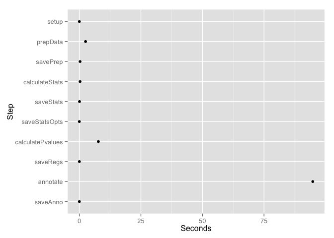

```r
## Use this information to make a plot
timed <- diff(results$timeinfo)
timed.df <- data.frame(Seconds = as.numeric(timed), Step = factor(names(timed),
    levels = rev(names(timed))))
library('ggplot2')
ggplot(timed.df, aes(y = Step, x = Seconds)) + geom_point()
```

## 6.4 Merge results

Once you have analyzed each chromosome using `analyzeChr()`, you can use `mergeResults()` to merge the results. This function does not return an object in R but instead creates several Rdata files with the main results from the different chromosomes.

```r
## Go back to the original directory
setwd(originalWd)

## Merge results from several chromosomes. In this case we only have one.
mergeResults(chrs='chr21', prefix="analysisResults",
    genomicState = genomicState$fullGenome,
    optionsStats = results$optionsStats)
```

```
## 2015-11-11 18:49:59 mergeResults: Saving options used
## 2015-11-11 18:49:59 Loading chromosome chr21
## 2015-11-11 18:49:59 mergeResults: calculating FWER
## 2015-11-11 18:49:59 mergeResults: Saving fullNullSummary
## 2015-11-11 18:49:59 mergeResults: Re-calculating the p-values
## 2015-11-11 18:49:59 mergeResults: Saving fullRegions
## 2015-11-11 18:49:59 mergeResults: assigning genomic states
## 2015-11-11 18:49:59 annotateRegions: counting
## 2015-11-11 18:50:00 annotateRegions: annotating
## 2015-11-11 18:50:00 mergeResults: Saving fullAnnotatedRegions
## 2015-11-11 18:50:00 mergeResults: Saving fullFstats
## 2015-11-11 18:50:00 mergeResults: Saving fullTime
```

```r
## Files created by mergeResults()
dir('analysisResults', pattern = '.Rdata')
```

```
## [1] "fullAnnotatedRegions.Rdata" "fullFstats.Rdata"
## [3] "fullNullSummary.Rdata"      "fullRegions.Rdata"
## [5] "fullTime.Rdata"             "optionsMerge.Rdata"
```

- *fullFstats.Rdata* contains a list with one element per chromosome. Per chromosome it has the F-statistics.
- *fullNullSummary.Rdata* is a list with the summary information from the null regions stored for each chromosome.
- *fullTime.Rdata* has the timing information for each chromosome as a list.

### 6.4.1 optionsMerge

For reproducibility purposes, the options used the merge the results are stored in `optionsMerge`.

```r
## Options used to merge
load(file.path('analysisResults', 'optionsMerge.Rdata'))

## Contents
names(optionsMerge)
```

```
## [1] "chrs"            "significantCut"  "minoverlap"      "mergeCall"
## [5] "cutoffFstatUsed" "optionsStats"
```

```r
## Merge call
optionsMerge$mergeCall
```

```
## mergeResults(chrs = "chr21", prefix = "analysisResults", genomicState = genomicState$fullGenome,
##     optionsStats = results$optionsStats)
```

### 6.4.2 fullRegions

The main result from `mergeResults()` is in `fullRegions`. This is a `GRanges` object with the candidate DERs from all the chromosomes. It also includes the nearest annotation metadata as well as FWER adjusted p-values (*fwer*) and whether the FWER adjusted p-value is less than 0.05 (*significantFWER*).

```r
## Load all the regions
load(file.path('analysisResults', 'fullRegions.Rdata'))

## Metadata columns
names(mcols(fullRegions))
```

```
##  [1] "value"                      "area"
##  [3] "indexStart"                 "indexEnd"
##  [5] "cluster"                    "clusterL"
##  [7] "meanCoverage"               "meanfetal"
##  [9] "meanadult"                  "log2FoldChangeadultvsfetal"
## [11] "pvalues"                    "significant"
## [13] "qvalues"                    "significantQval"
## [15] "name"                       "annotation"
## [17] "description"                "region"
## [19] "distance"                   "subregion"
## [21] "insideDistance"             "exonnumber"
## [23] "nexons"                     "UTR"
## [25] "annoStrand"                 "geneL"
## [27] "codingL"                    "Entrez"
## [29] "subjectHits"                "fwer"
## [31] "significantFWER"
```

Note that `analyzeChr()` only has the information for a given chromosome at a time, so `mergeResults()` re-calculates the p-values and q-values using the information from all the chromosomes.

### 6.4.3 fullAnnotatedRegions

In preparation for visually exploring the results, `mergeResults()` will run `annotateRegions()` which counts how many known exons, introns and intergenic segments each candidate DER overlaps (by default with a minimum overlap of 20bp). `annotateRegions()` uses a summarized version of the genome annotation created with `makeGenomicState()`. For this example, we can use the data included in *[derfinder](http://bioconductor.org/packages/release/bioc/html/derfinder.html)* which is the summarized annotation of hg19 for chromosome 21.

```r
## Load annotateRegions() output
load(file.path('analysisResults', 'fullAnnotatedRegions.Rdata'))

## Information stored
names(fullAnnotatedRegions)
```

```
## [1] "countTable"     "annotationList"
```

```r
## Take a peak
lapply(fullAnnotatedRegions, head)
```

```
## $countTable
##   exon intergenic intron
## 1    1          0      0
## 2    1          0      0
## 3    1          0      0
## 4    1          0      0
## 5    0          1      0
## 6    1          0      0
##
## $annotationList
## GRangesList object of length 6:
## $1
## GRanges object with 1 range and 4 metadata columns:
##        seqnames               ranges strand |   theRegion
##           <Rle>            <IRanges>  <Rle> | <character>
##   4871    chr21 [47609038, 47611149]      - |        exon
##                        tx_id                              tx_name
##                <IntegerList>                      <CharacterList>
##   4871 73448,73449,73450,... uc002zij.3,uc002zik.2,uc002zil.2,...
##                 gene
##        <IntegerList>
##   4871           170
##
## $2
## GRanges object with 1 range and 4 metadata columns:
##        seqnames               ranges strand | theRegion       tx_id
##   1189    chr21 [40194598, 40196878]      + |      exon 72757,72758
##                      tx_name gene
##   1189 uc002yxf.3,uc002yxg.4   77
##
## $3
## GRanges object with 1 range and 4 metadata columns:
##        seqnames               ranges strand | theRegion
##   2965    chr21 [27252861, 27254082]      - |      exon
##                        tx_id                              tx_name gene
##   2965 73066,73067,73068,... uc002ylz.3,uc002yma.3,uc002ymb.3,...  139
##
## ...
## <3 more elements>
## -------
## seqinfo: 1 sequence from hg19 genome
```